# Network Intrusion Detection System (IDS)

Imports

```python
import pandas as pd
import numpy as np
import tensorflow as tf
from collections.abc import Sequence
from sklearn.model_selection import train_test_split
from sklearn import preprocessing
import matplotlib.pyplot as plt
import shutil
import os
from tensorflow.keras.models import Sequential
from tensorflow.keras.layers import Dense, Dropout, Flatten
from tensorflow.keras.layers import Conv2D, MaxPooling2D
%matplotlib inline
from sklearn.metrics import roc_curve, auc
from sklearn import svm, datasets
from sklearn.metrics import confusion_matrix, classification_report
from tensorflow.keras.datasets import mnist
from tensorflow.keras.callbacks import EarlyStopping
from tensorflow.keras import optimizers
from tensorflow.keras.callbacks import ModelCheckpoint
from sklearn import metrics
from tensorflow.keras.layers import Dense, Activation, Dropout
from tensorflow.keras import optimizers
```

Helper functions

```python
def encode_text_dummy(df, name):
    dummies = pd.get_dummies(df[name])
    for x in dummies.columns:
        dummy_name = "{}-{}".format(name, x)
        df[dummy_name] = dummies[x]
    df.drop(name, axis=1, inplace=True)

def encode_numeric_range(df, name, normalized_low=-1, normalized_high=1,
                         data_low=None, data_high=None):
    if data_low is None:
        data_low = min(df[name])
        data_high = max(df[name])

    df[name] = ((df[name] - data_low) / (data_high - data_low)) \
               * (normalized_high - normalized_low) + normalized_low
# Convert all missing values in the specified column to the median
def missing_median(df, name):
    med = df[name].median()
    df[name] = df[name].fillna(med)

# Convert a Pandas dataframe to the x,y inputs that TensorFlow needs
def to_xy(df, target):
    result = []
    for x in df.columns:
        if x != target:
            result.append(x)
    # find out the type of the target column.
    target_type = df[target].dtypes
    target_type = target_type[0] if isinstance(target_type, Sequence) else target_type
    # Encode to int for classification, float otherwise. TensorFlow likes 32 bits.
    if target_type in (np.int64, np.int32):
        # Classification
        dummies = pd.get_dummies(df[target])
        return df[result].values.astype(np.float32), dummies.values.astype(np.float32)
    else:
        # Regression
        return df[result].values.astype(np.float32), df[target].values.astype(np.float32)

# Encode text values to indexes(i.e. [1],[2],[3] for red,green,blue).
def encode_text_index(df, name):
    le = preprocessing.LabelEncoder()
    df[name] = le.fit_transform(df[name])
    return le.classes_


# Plot a confusion matrix.
# cm is the confusion matrix, names are the names of the classes.
def plot_confusion_matrix(cm, names, title='Confusion matrix', cmap=plt.cm.Blues):
    plt.imshow(cm, interpolation='nearest', cmap=cmap)
    plt.title(title)
    plt.colorbar()
    tick_marks = np.arange(len(names))
    plt.xticks(tick_marks, names, rotation=45)
    plt.yticks(tick_marks, names)
    plt.tight_layout()
    plt.ylabel('True label')
    plt.xlabel('Predicted label')


# Plot an ROC. pred - the predictions, y - the expected output.
def plot_roc(pred,y):
    fpr, tpr, thresholds = roc_curve(y, pred)
    roc_auc = auc(fpr, tpr)

    plt.figure()
    plt.plot(fpr, tpr, label='ROC curve (area = %0.2f)' % roc_auc)
    plt.plot([0, 1], [0, 1], 'k--')
    plt.xlim([0.0, 1.0])
    plt.ylim([0.0, 1.05])
    plt.xlabel('False Positive Rate')
    plt.ylabel('True Positive Rate')
    plt.title('Receiver Operating Characteristic (ROC)')
    plt.legend(loc="lower right")
    plt.show()

# Nicely formatted time string
def hms_string(sec_elapsed):
    h = int(sec_elapsed / (60 * 60))
    m = int((sec_elapsed % (60 * 60)) / 60)
    s = sec_elapsed % 60
    return "{}:{:>02}:{:>05.2f}".format(h, m, s)
```

## Load Data, Pre-Process Data, Clean Up Data

Read the data and dealth with missing values

```python
df = pd.read_csv('data.csv',header=None,na_values=['NA','?'])
```

Gave column names to the data

```python
df.columns = [ 'duration', 'protocol_type', 'service', 'flag', 'src_bytes', 'dst_bytes', 'land', 'wrong_fragment', 'urgent',
 'hot', 'num_failed_logins', 'logged_in', 'num_compromised', 'root_shell', 'su_attempted', 'num_root', 'num_file_creations',
 'num_shells', 'num_access_files', 'num_outbound_cmds', 'is_host_login', 'is_guest_login', 'count', 'srv_count', 'serror_rate',
 'srv_serror_rate', 'rerror_rate', 'srv_rerror_rate', 'same_srv_rate', 'diff_srv_rate', 'srv_diff_host_rate', 'dst_host_count',
 'dst_host_srv_count', 'dst_host_same_srv_rate', 'dst_host_diff_srv_rate', 'dst_host_same_src_port_rate', 'dst_host_srv_diff_host_rate',
 'dst_host_serror_rate', 'dst_host_srv_serror_rate', 'dst_host_rerror_rate', 'dst_host_srv_rerror_rate', 'outcome']
```

```python
df.head()
```

|  | duration | protocol_type | service | flag | src_bytes | dst_bytes | land | wrong_fragment | urgent | hot | ... | dst_host_srv_count | dst_host_same_srv_rate | dst_host_diff_srv_rate | dst_host_same_src_port_rate | dst_host_srv_diff_host_rate | dst_host_serror_rate | dst_host_srv_serror_rate | dst_host_rerror_rate | dst_host_srv_rerror_rate | outcome |
| --- | --- | --- | --- | --- | --- | --- | --- | --- | --- | --- | --- | --- | --- | --- | --- | --- | --- | --- | --- | --- | --- |
| 0 | 0 | tcp | http | SF | 181 | 5450 | 0 | 0 | 0 | 0 | ... | 9 | 1.0 | 0.0 | 0.11 | 0.0 | 0.0 | 0.0 | 0.0 | 0.0 | normal. |
| 1 | 0 | tcp | http | SF | 239 | 486 | 0 | 0 | 0 | 0 | ... | 19 | 1.0 | 0.0 | 0.05 | 0.0 | 0.0 | 0.0 | 0.0 | 0.0 | normal. |
| 2 | 0 | tcp | http | SF | 235 | 1337 | 0 | 0 | 0 | 0 | ... | 29 | 1.0 | 0.0 | 0.03 | 0.0 | 0.0 | 0.0 | 0.0 | 0.0 | normal. |
| 3 | 0 | tcp | http | SF | 219 | 1337 | 0 | 0 | 0 | 0 | ... | 39 | 1.0 | 0.0 | 0.03 | 0.0 | 0.0 | 0.0 | 0.0 | 0.0 | normal. |
| 4 | 0 | tcp | http | SF | 217 | 2032 | 0 | 0 | 0 | 0 | ... | 49 | 1.0 | 0.0 | 0.02 | 0.0 | 0.0 | 0.0 | 0.0 | 0.0 | normal. |

5 rows × 42 columns

```python
df.shape
```

```
(494021, 42)
```

Displayed all the different possible outcomes

```python
outcomes=df["outcome"].unique()
print(", ".join(outcomes)+".")
```

```
normal., buffer_overflow., loadmodule., perl., neptune., smurf., guess_passwd., pod., teardrop., portsweep., ipsweep., land., ftp_write., back., imap., satan., phf., nmap., multihop., warezmaster., warezclient., spy., rootkit..
```

Classified all the different intrusions and attacks into a group "attacks"

```python
attacks=["back.","buffer_overflow.","ftp_write.", "guess_passwd.",
       "imap.", "ipsweep.", "land.", "loadmodule.", "multihop.",
       "neptune.", "nmap.","perl.", "phf.", "pod.",
       "portsweep.", "rootkit.", "satan.", "smurf.", "spy.", "teardrop.",
       "warezclient.", "warezmaster."]
classes=["normal","attack"]
```

Loop through all the 'outcome', and if it is part of 'attacks' then mark it as attack. Otherwise, it is normal

```python
def attack_label (row):
    if row["outcome"] in attacks:
        return classes[1]
    return classes[0]
```

```python
df["result"]=df.apply(attack_label,axis=1)
```

```python
outcomes=df["result"].unique()
print(", ".join(outcomes)+".")
```

```
normal, attack.
```

Broke up all the columns into either categorical or numerical

```python
categorical=["protocol_type","service","flag"]
numerical=[ 'duration','src_bytes', 'dst_bytes', 'land', 'wrong_fragment', 'urgent',
 'hot', 'num_failed_logins', 'logged_in', 'num_compromised', 'root_shell', 'su_attempted', 'num_root', 'num_file_creations',
 'num_shells', 'num_access_files', 'num_outbound_cmds', 'is_host_login', 'is_guest_login', 'count', 'srv_count', 'serror_rate',
 'srv_serror_rate', 'rerror_rate', 'srv_rerror_rate', 'same_srv_rate', 'diff_srv_rate', 'srv_diff_host_rate', 'dst_host_count',
 'dst_host_srv_count', 'dst_host_same_srv_rate', 'dst_host_diff_srv_rate', 'dst_host_same_src_port_rate', 'dst_host_srv_diff_host_rate',
 'dst_host_serror_rate', 'dst_host_srv_serror_rate', 'dst_host_rerror_rate', 'dst_host_srv_rerror_rate']
```

Applied one hot encoding onto the categorical columns

```python
for column in df.columns :
    if column in categorical:
        encode_text_dummy(df,column)
```

```python
df.head()
```

|  | duration | src_bytes | dst_bytes | land | wrong_fragment | urgent | hot | num_failed_logins | logged_in | num_compromised | ... | flag-REJ | flag-RSTO | flag-RSTOS0 | flag-RSTR | flag-S0 | flag-S1 | flag-S2 | flag-S3 | flag-SF | flag-SH |
| --- | --- | --- | --- | --- | --- | --- | --- | --- | --- | --- | --- | --- | --- | --- | --- | --- | --- | --- | --- | --- | --- |
| 0 | 0 | 181 | 5450 | 0 | 0 | 0 | 0 | 0 | 1 | 0 | ... | 0 | 0 | 0 | 0 | 0 | 0 | 0 | 0 | 1 | 0 |
| 1 | 0 | 239 | 486 | 0 | 0 | 0 | 0 | 0 | 1 | 0 | ... | 0 | 0 | 0 | 0 | 0 | 0 | 0 | 0 | 1 | 0 |
| 2 | 0 | 235 | 1337 | 0 | 0 | 0 | 0 | 0 | 1 | 0 | ... | 0 | 0 | 0 | 0 | 0 | 0 | 0 | 0 | 1 | 0 |
| 3 | 0 | 219 | 1337 | 0 | 0 | 0 | 0 | 0 | 1 | 0 | ... | 0 | 0 | 0 | 0 | 0 | 0 | 0 | 0 | 1 | 0 |
| 4 | 0 | 217 | 2032 | 0 | 0 | 0 | 0 | 0 | 1 | 0 | ... | 0 | 0 | 0 | 0 | 0 | 0 | 0 | 0 | 1 | 0 |

5 rows × 120 columns

```python
df.drop_duplicates()
```

|  | duration | src_bytes | dst_bytes | land | wrong_fragment | urgent | hot | num_failed_logins | logged_in | num_compromised | ... | flag-REJ | flag-RSTO | flag-RSTOS0 | flag-RSTR | flag-S0 | flag-S1 | flag-S2 | flag-S3 | flag-SF | flag-SH |
| --- | --- | --- | --- | --- | --- | --- | --- | --- | --- | --- | --- | --- | --- | --- | --- | --- | --- | --- | --- | --- | --- |
| 0 | 0 | 181 | 5450 | 0 | 0 | 0 | 0 | 0 | 1 | 0 | ... | 0 | 0 | 0 | 0 | 0 | 0 | 0 | 0 | 1 | 0 |
| 1 | 0 | 239 | 486 | 0 | 0 | 0 | 0 | 0 | 1 | 0 | ... | 0 | 0 | 0 | 0 | 0 | 0 | 0 | 0 | 1 | 0 |
| 2 | 0 | 235 | 1337 | 0 | 0 | 0 | 0 | 0 | 1 | 0 | ... | 0 | 0 | 0 | 0 | 0 | 0 | 0 | 0 | 1 | 0 |
| 3 | 0 | 219 | 1337 | 0 | 0 | 0 | 0 | 0 | 1 | 0 | ... | 0 | 0 | 0 | 0 | 0 | 0 | 0 | 0 | 1 | 0 |
| 4 | 0 | 217 | 2032 | 0 | 0 | 0 | 0 | 0 | 1 | 0 | ... | 0 | 0 | 0 | 0 | 0 | 0 | 0 | 0 | 1 | 0 |
| ... | ... | ... | ... | ... | ... | ... | ... | ... | ... | ... | ... | ... | ... | ... | ... | ... | ... | ... | ... | ... | ... |
| 494016 | 0 | 310 | 1881 | 0 | 0 | 0 | 0 | 0 | 1 | 0 | ... | 0 | 0 | 0 | 0 | 0 | 0 | 0 | 0 | 1 | 0 |
| 494017 | 0 | 282 | 2286 | 0 | 0 | 0 | 0 | 0 | 1 | 0 | ... | 0 | 0 | 0 | 0 | 0 | 0 | 0 | 0 | 1 | 0 |
| 494018 | 0 | 203 | 1200 | 0 | 0 | 0 | 0 | 0 | 1 | 0 | ... | 0 | 0 | 0 | 0 | 0 | 0 | 0 | 0 | 1 | 0 |
| 494019 | 0 | 291 | 1200 | 0 | 0 | 0 | 0 | 0 | 1 | 0 | ... | 0 | 0 | 0 | 0 | 0 | 0 | 0 | 0 | 1 | 0 |
| 494020 | 0 | 219 | 1234 | 0 | 0 | 0 | 0 | 0 | 1 | 0 | ... | 0 | 0 | 0 | 0 | 0 | 0 | 0 | 0 | 1 | 0 |

145586 rows × 120 columns

Normalized the numerical columns and filled in the missing values with the median

```python
for column in df.columns:
    if column in numerical:
        encode_numeric_range(df,column)
        missing_median(df,column)
```

```python
df.shape
```

```
(494021, 120)
```

Dropped uncessary columns and prepped the data for our model

```python
df.drop('outcome',axis=1,inplace=True)
df.drop('num_outbound_cmds',axis=1,inplace=True)
df.drop('is_host_login',axis=1,inplace=True)
result=encode_text_index(df,'result')
x,y=to_xy(df,'result')
```

```python
x.shape
```

```
(494021, 116)
```

Split the data into 20% test and 80% train

```python
x_train, x_test, y_train, y_test = train_test_split(x, y, test_size=0.2, random_state=42)
```

```python
print(x_train.shape)
print(y_train.shape)
print(x_test.shape)
print(y_test.shape)
```

```
(395216, 116)
(395216, 2)
(98805, 116)
(98805, 2)
```

## Train the Model

Tuning the different parameters and taking note of the different results. Different parameters include Activision: relu, sigmoid, tanh. Number of layers and neurons. Optimizer:adam, sgd. Kernel number and kernel size (CNN only)

### Fully-Connected Neural Networks

Trial 1: sigmoid, sgd, many layers, 256 neurons

```python
checkpointer = ModelCheckpoint(filepath="dnn/best_weights.hdf5", verbose=0, save_best_only=True)
for i in range(5):
    print(i)

    model = Sequential()
    model.add(Dense(256, input_dim=x.shape[1], activation='sigmoid'))
    model.add(Dense(256))
    model.add(Dense(256))
    model.add(Dense(256))
    model.add(Dense(y.shape[1], activation='sigmoid'))

    adam = optimizers.Adam(lr=0.0001, beta_1=0.9, beta_2=0.999, epsilon=None, decay=0.0, amsgrad=False)
    sgd = optimizers.SGD(lr=0.0001)
    model.compile(loss='mean_squared_error', optimizer=sgd)

    monitor = EarlyStopping(monitor='val_loss', min_delta=1e-3, patience=5, verbose=1, mode='auto')



    model.fit(x_train,y_train,validation_data=(x_test,y_test), batch_size= 128, callbacks=[monitor,checkpointer],verbose=2,epochs=1000)



model.load_weights('dnn/best_weights.hdf5')

# Predict and measure RMSE
pred = model.predict(x_test)

score = np.sqrt(metrics.mean_squared_error(pred,y_test))
print("Score (RMSE): {}".format(score))
```

```
0
WARNING:tensorflow:From C:\Users\omgit\anaconda3\lib\site-packages\tensorflow\python\ops\init_ops.py:1251: calling VarianceScaling.__init__ (from tensorflow.python.ops.init_ops) with dtype is deprecated and will be removed in a future version.
Instructions for updating:
Call initializer instance with the dtype argument instead of passing it to the constructor
Train on 395216 samples, validate on 98805 samples
395216/395216 - 10s - loss: 0.1615 - val_loss: 0.1506
395216/395216 - 10s - loss: 0.1495 - val_loss: 0.1470
395216/395216 - 10s - loss: 0.1457 - val_loss: 0.1431
395216/395216 - 10s - loss: 0.1417 - val_loss: 0.1389
395216/395216 - 9s - loss: 0.1372 - val_loss: 0.1344
395216/395216 - 10s - loss: 0.1324 - val_loss: 0.1294
395216/395216 - 10s - loss: 0.1272 - val_loss: 0.1240
395216/395216 - 9s - loss: 0.1215 - val_loss: 0.1181
395216/395216 - 9s - loss: 0.1153 - val_loss: 0.1117
395216/395216 - 9s - loss: 0.1087 - val_loss: 0.1049
395216/395216 - 9s - loss: 0.1016 - val_loss: 0.0978
395216/395216 - 9s - loss: 0.0943 - val_loss: 0.0904
395216/395216 - 9s - loss: 0.0869 - val_loss: 0.0830
395216/395216 - 9s - loss: 0.0795 - val_loss: 0.0758
395216/395216 - 9s - loss: 0.0724 - val_loss: 0.0689
395216/395216 - 9s - loss: 0.0657 - val_loss: 0.0625
395216/395216 - 9s - loss: 0.0595 - val_loss: 0.0568
395216/395216 - 9s - loss: 0.0541 - val_loss: 0.0516
395216/395216 - 9s - loss: 0.0492 - val_loss: 0.0472
395216/395216 - 10s - loss: 0.0450 - val_loss: 0.0433
395216/395216 - 11s - loss: 0.0414 - val_loss: 0.0400
395216/395216 - 10s - loss: 0.0383 - val_loss: 0.0371
395216/395216 - 9s - loss: 0.0356 - val_loss: 0.0346
395216/395216 - 9s - loss: 0.0333 - val_loss: 0.0325
395216/395216 - 9s - loss: 0.0313 - val_loss: 0.0306
395216/395216 - 9s - loss: 0.0296 - val_loss: 0.0290
395216/395216 - 9s - loss: 0.0281 - val_loss: 0.0276
395216/395216 - 9s - loss: 0.0267 - val_loss: 0.0264
395216/395216 - 9s - loss: 0.0256 - val_loss: 0.0253
395216/395216 - 10s - loss: 0.0245 - val_loss: 0.0243
395216/395216 - 9s - loss: 0.0236 - val_loss: 0.0235
395216/395216 - 10s - loss: 0.0228 - val_loss: 0.0227
395216/395216 - 9s - loss: 0.0220 - val_loss: 0.0220
395216/395216 - 10s - loss: 0.0214 - val_loss: 0.0213
395216/395216 - 9s - loss: 0.0207 - val_loss: 0.0208
```

[output cut: 246 more lines]

```
395216/395216 - 10s - loss: 0.0173 - val_loss: 0.0174
395216/395216 - 10s - loss: 0.0170 - val_loss: 0.0171
395216/395216 - 10s - loss: 0.0167 - val_loss: 0.0169
395216/395216 - 10s - loss: 0.0165 - val_loss: 0.0167
395216/395216 - 10s - loss: 0.0163 - val_loss: 0.0165
395216/395216 - 10s - loss: 0.0161 - val_loss: 0.0162
395216/395216 - 10s - loss: 0.0159 - val_loss: 0.0161
395216/395216 - 10s - loss: 0.0157 - val_loss: 0.0159
395216/395216 - 10s - loss: 0.0155 - val_loss: 0.0157
395216/395216 - 10s - loss: 0.0154 - val_loss: 0.0155
395216/395216 - 10s - loss: 0.0152 - val_loss: 0.0154
395216/395216 - 10s - loss: 0.0150 - val_loss: 0.0152
395216/395216 - 10s - loss: 0.0149 - val_loss: 0.0151
Epoch 00058: early stopping
Score (RMSE): 0.12198243290185928
```

Trial 2: tanh, adam, less hidden layers and less neurons

```python
checkpointer = ModelCheckpoint(filepath="dnn/best_weights.hdf5", verbose=0, save_best_only=True)
for i in range(2):
    print(i)

    model = Sequential()
    model.add(Dense(10, input_dim=x.shape[1], activation='tanh'))
    model.add(Dense(10))
    model.add(Dense(y.shape[1], activation='tanh'))

    adam = optimizers.Adam(lr=0.0001, beta_1=0.9, beta_2=0.999, epsilon=None, decay=0.0, amsgrad=False)
    sgd = optimizers.SGD(lr=0.0001)
    model.compile(loss='mean_squared_error', optimizer=adam)

    monitor = EarlyStopping(monitor='val_loss', min_delta=1e-3, patience=5, verbose=1, mode='auto')


    model.fit(x_train,y_train,validation_data=(x_test,y_test), batch_size= 128, callbacks=[monitor,checkpointer],verbose=2,epochs=1000)



model.load_weights('dnn/best_weights.hdf5')

# Predict and measure RMSE
pred = model.predict(x_test)

score = np.sqrt(metrics.mean_squared_error(pred,y_test))
print("Score (RMSE): {}".format(score))
```

```
0
Train on 395216 samples, validate on 98805 samples
395216/395216 - 4s - loss: 0.0322 - val_loss: 0.0105
395216/395216 - 3s - loss: 0.0090 - val_loss: 0.0084
395216/395216 - 3s - loss: 0.0077 - val_loss: 0.0076
395216/395216 - 3s - loss: 0.0071 - val_loss: 0.0071
395216/395216 - 4s - loss: 0.0067 - val_loss: 0.0066
395216/395216 - 3s - loss: 0.0063 - val_loss: 0.0063
395216/395216 - 3s - loss: 0.0061 - val_loss: 0.0061
395216/395216 - 3s - loss: 0.0058 - val_loss: 0.0058
395216/395216 - 4s - loss: 0.0056 - val_loss: 0.0057
395216/395216 - 3s - loss: 0.0054 - val_loss: 0.0054
395216/395216 - 3s - loss: 0.0052 - val_loss: 0.0053
395216/395216 - 3s - loss: 0.0050 - val_loss: 0.0051
395216/395216 - 3s - loss: 0.0049 - val_loss: 0.0049
Epoch 00013: early stopping
1
Train on 395216 samples, validate on 98805 samples
395216/395216 - 4s - loss: 0.0677 - val_loss: 0.0151
395216/395216 - 3s - loss: 0.0120 - val_loss: 0.0100
395216/395216 - 3s - loss: 0.0087 - val_loss: 0.0081
395216/395216 - 3s - loss: 0.0075 - val_loss: 0.0074
395216/395216 - 3s - loss: 0.0070 - val_loss: 0.0070
395216/395216 - 3s - loss: 0.0066 - val_loss: 0.0066
395216/395216 - 3s - loss: 0.0063 - val_loss: 0.0063
395216/395216 - 4s - loss: 0.0060 - val_loss: 0.0060
395216/395216 - 4s - loss: 0.0058 - val_loss: 0.0057
395216/395216 - 3s - loss: 0.0055 - val_loss: 0.0055
395216/395216 - 3s - loss: 0.0054 - val_loss: 0.0053
395216/395216 - 3s - loss: 0.0052 - val_loss: 0.0053
395216/395216 - 4s - loss: 0.0050 - val_loss: 0.0051
395216/395216 - 4s - loss: 0.0048 - val_loss: 0.0049
Epoch 00014: early stopping
Score (RMSE): 0.06974583119153976
```

Trial 3:relu, adam, many hidden layers and less neurons

```python
checkpointer = ModelCheckpoint(filepath="dnn/best_weights.hdf5", verbose=0, save_best_only=True)
for i in range(2):
    print(i)

    model = Sequential()
    model.add(Dense(3, input_dim=x.shape[1], activation='relu'))
    model.add(Dense(3))
    model.add(Dense(3))
    model.add(Dense(3))
    model.add(Dense(y.shape[1], activation='relu'))

    adam = optimizers.Adam(lr=0.0001, beta_1=0.9, beta_2=0.999, epsilon=None, decay=0.0, amsgrad=False)
    sgd = optimizers.SGD(lr=0.0001)
    model.compile(loss='mean_squared_error', optimizer=adam)

    monitor = EarlyStopping(monitor='val_loss', min_delta=1e-3, patience=5, verbose=1, mode='auto')



    model.fit(x_train,y_train,validation_data=(x_test,y_test), batch_size= 128, callbacks=[monitor,checkpointer],verbose=2,epochs=1000)



model.load_weights('dnn/best_weights.hdf5')

# Predict and measure RMSE
pred = model.predict(x_test)

score = np.sqrt(metrics.mean_squared_error(pred,y_test))
print("Score (RMSE): {}".format(score))
```

```
0
Train on 395216 samples, validate on 98805 samples
395216/395216 - 5s - loss: 0.2749 - val_loss: 0.0407
395216/395216 - 4s - loss: 0.0387 - val_loss: 0.0379
395216/395216 - 4s - loss: 0.0327 - val_loss: 0.0312
395216/395216 - 4s - loss: 0.0304 - val_loss: 0.0303
395216/395216 - 4s - loss: 0.0299 - val_loss: 0.0300
395216/395216 - 4s - loss: 0.0296 - val_loss: 0.0297
395216/395216 - 4s - loss: 0.0294 - val_loss: 0.0296
395216/395216 - 4s - loss: 0.0292 - val_loss: 0.0288
395216/395216 - 4s - loss: 0.0083 - val_loss: 0.0071
395216/395216 - 3s - loss: 0.0066 - val_loss: 0.0066
395216/395216 - 3s - loss: 0.0063 - val_loss: 0.0063
395216/395216 - 3s - loss: 0.0061 - val_loss: 0.0062
395216/395216 - 3s - loss: 0.0060 - val_loss: 0.0061
395216/395216 - 3s - loss: 0.0056 - val_loss: 0.0056
395216/395216 - 3s - loss: 0.0050 - val_loss: 0.0050
395216/395216 - 3s - loss: 0.0047 - val_loss: 0.0048
395216/395216 - 3s - loss: 0.0045 - val_loss: 0.0047
395216/395216 - 3s - loss: 0.0044 - val_loss: 0.0045
395216/395216 - 3s - loss: 0.0043 - val_loss: 0.0044
395216/395216 - 3s - loss: 0.0042 - val_loss: 0.0043
Epoch 00020: early stopping
1
Train on 395216 samples, validate on 98805 samples
395216/395216 - 4s - loss: 0.1651 - val_loss: 0.1142
395216/395216 - 3s - loss: 0.1061 - val_loss: 0.1030
395216/395216 - 3s - loss: 0.1033 - val_loss: 0.1025
395216/395216 - 3s - loss: 0.1029 - val_loss: 0.1021
395216/395216 - 3s - loss: 0.1025 - val_loss: 0.1018
395216/395216 - 3s - loss: 0.1023 - val_loss: 0.1017
395216/395216 - 3s - loss: 0.1023 - val_loss: 0.1016
395216/395216 - 3s - loss: 0.1022 - val_loss: 0.1016
395216/395216 - 3s - loss: 0.1022 - val_loss: 0.1016
395216/395216 - 3s - loss: 0.1021 - val_loss: 0.1015
Epoch 00010: early stopping
Score (RMSE): 0.0656951367855072
```

Trial 4:tanh, sgd, less hidden layers and less neurons

```python
checkpointer = ModelCheckpoint(filepath="dnn/best_weights.hdf5", verbose=0, save_best_only=True)
for i in range(2):
    print(i)

    model = Sequential()
    model.add(Dense(10, input_dim=x.shape[1], activation='tanh'))
    model.add(Dense(10))
    model.add(Dense(y.shape[1], activation='tanh'))

    adam = optimizers.Adam(lr=0.0001, beta_1=0.9, beta_2=0.999, epsilon=None, decay=0.0, amsgrad=False)
    sgd = optimizers.SGD(lr=0.0001)
    model.compile(loss='mean_squared_error', optimizer=sgd)

    monitor = EarlyStopping(monitor='val_loss', min_delta=1e-3, patience=5, verbose=1, mode='auto')



    model.fit(x_train,y_train,validation_data=(x_test,y_test), batch_size= 128, callbacks=[monitor,checkpointer],verbose=2,epochs=1000)



model.load_weights('dnn/best_weights.hdf5')

# Predict and measure RMSE
pred = model.predict(x_test)

score = np.sqrt(metrics.mean_squared_error(pred,y_test))
print("Score (RMSE): {}".format(score))
```

```
0
Train on 395216 samples, validate on 98805 samples
395216/395216 - 4s - loss: 0.1948 - val_loss: 0.0633
395216/395216 - 3s - loss: 0.0443 - val_loss: 0.0338
395216/395216 - 3s - loss: 0.0292 - val_loss: 0.0268
395216/395216 - 3s - loss: 0.0248 - val_loss: 0.0239
395216/395216 - 3s - loss: 0.0226 - val_loss: 0.0223
395216/395216 - 3s - loss: 0.0213 - val_loss: 0.0212
395216/395216 - 3s - loss: 0.0203 - val_loss: 0.0203
395216/395216 - 3s - loss: 0.0195 - val_loss: 0.0195
395216/395216 - 3s - loss: 0.0188 - val_loss: 0.0189
395216/395216 - 3s - loss: 0.0182 - val_loss: 0.0183
395216/395216 - 3s - loss: 0.0177 - val_loss: 0.0178
395216/395216 - 3s - loss: 0.0172 - val_loss: 0.0174
395216/395216 - 3s - loss: 0.0168 - val_loss: 0.0170
395216/395216 - 3s - loss: 0.0165 - val_loss: 0.0166
395216/395216 - 3s - loss: 0.0161 - val_loss: 0.0163
395216/395216 - 3s - loss: 0.0159 - val_loss: 0.0160
395216/395216 - 3s - loss: 0.0156 - val_loss: 0.0158
395216/395216 - 3s - loss: 0.0154 - val_loss: 0.0156
395216/395216 - 3s - loss: 0.0152 - val_loss: 0.0154
395216/395216 - 3s - loss: 0.0150 - val_loss: 0.0152
395216/395216 - 3s - loss: 0.0148 - val_loss: 0.0150
395216/395216 - 3s - loss: 0.0147 - val_loss: 0.0149
Epoch 00022: early stopping
1
Train on 395216 samples, validate on 98805 samples
395216/395216 - 3s - loss: 0.1290 - val_loss: 0.0747
395216/395216 - 3s - loss: 0.0632 - val_loss: 0.0546
395216/395216 - 3s - loss: 0.0495 - val_loss: 0.0453
395216/395216 - 3s - loss: 0.0422 - val_loss: 0.0395
395216/395216 - 3s - loss: 0.0374 - val_loss: 0.0356
395216/395216 - 3s - loss: 0.0340 - val_loss: 0.0328
395216/395216 - 3s - loss: 0.0316 - val_loss: 0.0308
395216/395216 - 3s - loss: 0.0299 - val_loss: 0.0293
395216/395216 - 3s - loss: 0.0285 - val_loss: 0.0281
395216/395216 - 3s - loss: 0.0274 - val_loss: 0.0271
395216/395216 - 3s - loss: 0.0265 - val_loss: 0.0262
395216/395216 - 3s - loss: 0.0257 - val_loss: 0.0255
395216/395216 - 3s - loss: 0.0250 - val_loss: 0.0248
395216/395216 - 3s - loss: 0.0243 - val_loss: 0.0241
395216/395216 - 3s - loss: 0.0237 - val_loss: 0.0236
395216/395216 - 3s - loss: 0.0231 - val_loss: 0.0230
395216/395216 - 3s - loss: 0.0226 - val_loss: 0.0225
395216/395216 - 3s - loss: 0.0222 - val_loss: 0.0221
395216/395216 - 3s - loss: 0.0217 - val_loss: 0.0216
395216/395216 - 3s - loss: 0.0213 - val_loss: 0.0212
395216/395216 - 3s - loss: 0.0209 - val_loss: 0.0209
395216/395216 - 3s - loss: 0.0206 - val_loss: 0.0205
395216/395216 - 3s - loss: 0.0202 - val_loss: 0.0202
395216/395216 - 3s - loss: 0.0199 - val_loss: 0.0199
395216/395216 - 3s - loss: 0.0196 - val_loss: 0.0196
395216/395216 - 3s - loss: 0.0194 - val_loss: 0.0194
395216/395216 - 3s - loss: 0.0191 - val_loss: 0.0191
395216/395216 - 3s - loss: 0.0189 - val_loss: 0.0189
395216/395216 - 3s - loss: 0.0187 - val_loss: 0.0187
395216/395216 - 3s - loss: 0.0185 - val_loss: 0.0185
395216/395216 - 3s - loss: 0.0183 - val_loss: 0.0183
395216/395216 - 3s - loss: 0.0181 - val_loss: 0.0181
Epoch 00032: early stopping
Score (RMSE): 0.12204744666814804
```

### Best Model

```python
checkpointer = ModelCheckpoint(filepath="dnn/best_weights.hdf5", verbose=0, save_best_only=True)
for i in range(5):
    print(i)

    model = Sequential()
    model.add(Dense(256, input_dim=x.shape[1], activation='relu'))
    model.add(Dense(256))
    model.add(Dense(256))
    model.add(Dense(256))
    model.add(Dense(y.shape[1], activation='relu'))

    adam = optimizers.Adam(lr=0.0001, beta_1=0.9, beta_2=0.999, epsilon=None, decay=0.0, amsgrad=False)
    sgd = optimizers.SGD(lr=0.0001)
    model.compile(loss='mean_squared_error', optimizer=adam)

    monitor = EarlyStopping(monitor='val_loss', min_delta=1e-3, patience=5, verbose=1, mode='auto')



    model.fit(x_train,y_train,validation_data=(x_test,y_test), batch_size= 128, callbacks=[monitor,checkpointer],verbose=2,epochs=1000)



model.load_weights('dnn/best_weights.hdf5')

# Predict and measure RMSE
pred = model.predict(x_test)

score = np.sqrt(metrics.mean_squared_error(pred,y_test))
print("Score (RMSE): {}".format(score))
```

```
0
Train on 395216 samples, validate on 98805 samples
395216/395216 - 13s - loss: 0.0060 - val_loss: 0.0030
395216/395216 - 12s - loss: 0.0025 - val_loss: 0.0026
395216/395216 - 12s - loss: 0.0017 - val_loss: 0.0014
395216/395216 - 13s - loss: 0.0014 - val_loss: 0.0019
395216/395216 - 13s - loss: 0.0012 - val_loss: 0.0013
395216/395216 - 13s - loss: 0.0011 - val_loss: 0.0011
395216/395216 - 13s - loss: 0.0010 - val_loss: 0.0013
395216/395216 - 13s - loss: 9.2221e-04 - val_loss: 0.0011
Epoch 00008: early stopping
1
Train on 395216 samples, validate on 98805 samples
395216/395216 - 13s - loss: 0.0080 - val_loss: 0.0030
395216/395216 - 13s - loss: 0.0022 - val_loss: 0.0016
395216/395216 - 13s - loss: 0.0015 - val_loss: 0.0015
395216/395216 - 12s - loss: 0.0013 - val_loss: 0.0012
395216/395216 - 12s - loss: 0.0011 - val_loss: 0.0012
395216/395216 - 13s - loss: 9.8816e-04 - val_loss: 9.2120e-04
395216/395216 - 12s - loss: 8.9718e-04 - val_loss: 0.0011
Epoch 00007: early stopping
2
Train on 395216 samples, validate on 98805 samples
395216/395216 - 13s - loss: 0.0067 - val_loss: 0.0028
395216/395216 - 12s - loss: 0.0023 - val_loss: 0.0019
395216/395216 - 12s - loss: 0.0016 - val_loss: 0.0020
395216/395216 - 12s - loss: 0.0013 - val_loss: 0.0013
395216/395216 - 12s - loss: 0.0011 - val_loss: 0.0013
395216/395216 - 13s - loss: 0.0010 - val_loss: 0.0014
395216/395216 - 12s - loss: 9.1576e-04 - val_loss: 9.5076e-04
395216/395216 - 13s - loss: 8.5592e-04 - val_loss: 0.0010
395216/395216 - 13s - loss: 8.2262e-04 - val_loss: 9.9788e-04
Epoch 00009: early stopping
3
Train on 395216 samples, validate on 98805 samples
395216/395216 - 13s - loss: 0.0060 - val_loss: 0.0030
395216/395216 - 12s - loss: 0.0023 - val_loss: 0.0027
395216/395216 - 13s - loss: 0.0016 - val_loss: 0.0015
395216/395216 - 13s - loss: 0.0013 - val_loss: 0.0013
395216/395216 - 13s - loss: 0.0012 - val_loss: 0.0012
395216/395216 - 13s - loss: 0.0010 - val_loss: 0.0010
395216/395216 - 14s - loss: 9.3143e-04 - val_loss: 8.9592e-04
395216/395216 - 12s - loss: 8.6303e-04 - val_loss: 8.8386e-04
Epoch 00008: early stopping
4
Train on 395216 samples, validate on 98805 samples
395216/395216 - 13s - loss: 0.0057 - val_loss: 0.0026
395216/395216 - 13s - loss: 0.0022 - val_loss: 0.0016
395216/395216 - 13s - loss: 0.0015 - val_loss: 0.0019
395216/395216 - 13s - loss: 0.0013 - val_loss: 0.0011
395216/395216 - 13s - loss: 0.0011 - val_loss: 0.0013
395216/395216 - 13s - loss: 0.0010 - val_loss: 0.0011
395216/395216 - 14s - loss: 9.1082e-04 - val_loss: 8.5130e-04
395216/395216 - 12s - loss: 8.5033e-04 - val_loss: 0.0011
395216/395216 - 13s - loss: 7.8530e-04 - val_loss: 0.0011
Epoch 00009: early stopping
Score (RMSE): 0.02918020822107792
```

## Data Results/Analysis

Using the trained model, showed different findings. We first Plotted the confusion matrix and displayed the precision, recall and f1-score of our model. Lastly we showed the RMSE score of our model.

```
[[79415    37]
 [   25 19328]]
Ploting confusion matrix
```

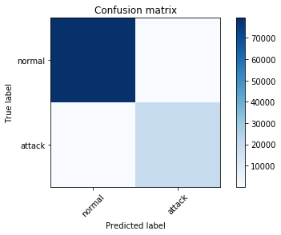

```
              precision    recall  f1-score   support

           0       1.00      1.00      1.00     79452
           1       1.00      1.00      1.00     19353

    accuracy                           1.00     98805
   macro avg       1.00      1.00      1.00     98805
weighted avg       1.00      1.00      1.00     98805

Score (RMSE): 0.02918020822107792
```

```python
pred2 = model.predict(x_test)
pred2 = np.argmax(pred,axis=1)
y_true = np.argmax(y_test,axis=1)

# Compute confusion matrix
cm = confusion_matrix(y_true, pred2)
print(cm)

print('Ploting confusion matrix')
plt.figure()
plot_confusion_matrix(cm, ('normal','attack'))
plt.show()


print(classification_report(y_true, pred2))
print("Score (RMSE): {}".format(score))
```

Display the ROC curve

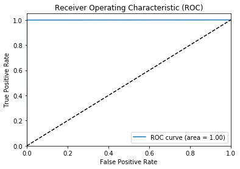

```python
plot_roc(pred2,y_true)
```

### Convolutional Neural Networks (CNN)

Reshape the x dataset into a 4d array

```python
xx = x.reshape((494021, 1, 116, 1))
```

Build the CNN model

Trial 1: sigmoid, sgd, 256 filters, kernel 1,2 stride 1

```python
cnn = Sequential()
cnn.add(Conv2D(256, kernel_size=(1, 2), strides=(1, 1),
                 activation='sigmoid',
                 input_shape=(1, 116, 1)))


cnn.add(MaxPooling2D(pool_size=(1,2)))

cnn.add(Conv2D(256, kernel_size=(1, 2), strides=(1, 1),
                 activation='tanh'))
cnn.add(MaxPooling2D(pool_size=(1,2)))


cnn.add(Flatten())
cnn.add(Dense(1024, activation="sigmoid"))
cnn.add(Dropout(0.5))
cnn.add(Dense(2, activation="softmax"))

# define optimizer and objective, compile cnn

cnn.compile(loss="categorical_crossentropy", optimizer="sgd")

x_train, x_test, y_train, y_test = train_test_split(xx, y, test_size=0.2, random_state=42)

import time

start_time = time.time()
checkpointer = ModelCheckpoint(filepath="dnn/best_weights.hdf5", verbose=0, save_best_only=True)
for i in range(5):
    print(i)

    monitor = EarlyStopping(monitor='val_loss', min_delta=1e-3, patience=5, verbose=1, mode='auto')
    cnn.fit(x_train[0:15000], y_train[0:15000],
              batch_size=64,
              epochs=10,
              verbose=2,
               callbacks=[monitor,checkpointer],
              validation_data=(x_test[0:300], y_test[0:300]))

pred2=cnn.predict(x_test)

score2 = np.sqrt(metrics.mean_squared_error(pred2,y_test))
print("Score (RMSE): {}".format(score2))

elapsed_time = time.time() - start_time
print("Elapsed time: {}".format(hms_string(elapsed_time)))
```

```
0
Train on 15000 samples, validate on 300 samples
15000/15000 - 16s - loss: 0.5710 - val_loss: 0.5025
15000/15000 - 17s - loss: 0.5398 - val_loss: 0.4750
15000/15000 - 15s - loss: 0.5228 - val_loss: 0.4517
15000/15000 - 15s - loss: 0.5157 - val_loss: 0.4503
15000/15000 - 15s - loss: 0.5109 - val_loss: 0.4484
15000/15000 - 15s - loss: 0.5082 - val_loss: 0.4544
15000/15000 - 15s - loss: 0.5027 - val_loss: 0.4481
15000/15000 - 15s - loss: 0.4995 - val_loss: 0.4446
15000/15000 - 15s - loss: 0.4985 - val_loss: 0.4439
15000/15000 - 15s - loss: 0.4969 - val_loss: 0.4587
1
Train on 15000 samples, validate on 300 samples
15000/15000 - 15s - loss: 0.4914 - val_loss: 0.4361
15000/15000 - 15s - loss: 0.4866 - val_loss: 0.4286
15000/15000 - 15s - loss: 0.4787 - val_loss: 0.4222
15000/15000 - 15s - loss: 0.4639 - val_loss: 0.4058
15000/15000 - 15s - loss: 0.4485 - val_loss: 0.3945
15000/15000 - 15s - loss: 0.4103 - val_loss: 0.3504
15000/15000 - 15s - loss: 0.3506 - val_loss: 0.2576
15000/15000 - 15s - loss: 0.2633 - val_loss: 0.1689
15000/15000 - 15s - loss: 0.1753 - val_loss: 0.1182
15000/15000 - 15s - loss: 0.1241 - val_loss: 0.0876
2
Train on 15000 samples, validate on 300 samples
15000/15000 - 15s - loss: 0.1027 - val_loss: 0.0774
15000/15000 - 15s - loss: 0.0878 - val_loss: 0.0684
15000/15000 - 15s - loss: 0.0804 - val_loss: 0.0645
15000/15000 - 15s - loss: 0.0761 - val_loss: 0.0630
15000/15000 - 15s - loss: 0.0758 - val_loss: 0.0622
15000/15000 - 15s - loss: 0.0730 - val_loss: 0.0610
15000/15000 - 15s - loss: 0.0702 - val_loss: 0.0578
15000/15000 - 15s - loss: 0.0694 - val_loss: 0.0614
15000/15000 - 15s - loss: 0.0672 - val_loss: 0.0567
15000/15000 - 16s - loss: 0.0673 - val_loss: 0.0548
3
Train on 15000 samples, validate on 300 samples
15000/15000 - 15s - loss: 0.0687 - val_loss: 0.0540
15000/15000 - 15s - loss: 0.0650 - val_loss: 0.0537
15000/15000 - 15s - loss: 0.0662 - val_loss: 0.0531
15000/15000 - 15s - loss: 0.0641 - val_loss: 0.0557
15000/15000 - 15s - loss: 0.0628 - val_loss: 0.0569
15000/15000 - 16s - loss: 0.0619 - val_loss: 0.0502
15000/15000 - 16s - loss: 0.0627 - val_loss: 0.0494
15000/15000 - 16s - loss: 0.0600 - val_loss: 0.0488
15000/15000 - 16s - loss: 0.0604 - val_loss: 0.0493
15000/15000 - 15s - loss: 0.0596 - val_loss: 0.0498
4
Train on 15000 samples, validate on 300 samples
15000/15000 - 16s - loss: 0.0583 - val_loss: 0.0476
15000/15000 - 15s - loss: 0.0580 - val_loss: 0.0466
15000/15000 - 15s - loss: 0.0564 - val_loss: 0.0468
15000/15000 - 15s - loss: 0.0571 - val_loss: 0.0449
15000/15000 - 15s - loss: 0.0573 - val_loss: 0.0451
15000/15000 - 15s - loss: 0.0549 - val_loss: 0.0438
15000/15000 - 15s - loss: 0.0563 - val_loss: 0.0434
15000/15000 - 15s - loss: 0.0549 - val_loss: 0.0495
15000/15000 - 15s - loss: 0.0535 - val_loss: 0.0427
15000/15000 - 15s - loss: 0.0547 - val_loss: 0.0419
Score (RMSE): 0.10994621366262436
Elapsed time: 0:13:17.92
```

```python
cnn = Sequential()
cnn.add(Conv2D(10, kernel_size=(1, 2), strides=(1, 1),
                 activation='tanh',
                 input_shape=(1, 116, 1)))


cnn.add(MaxPooling2D(pool_size=(1,2)))

cnn.add(Conv2D(10, kernel_size=(1, 2), strides=(1, 1),
                 activation='tanh'))
cnn.add(MaxPooling2D(pool_size=(1,2)))


cnn.add(Flatten())
cnn.add(Dense(1024, activation="tanh"))
cnn.add(Dropout(0.5))
cnn.add(Dense(2, activation="softmax"))

# define optimizer and objective, compile cnn

cnn.compile(loss="categorical_crossentropy", optimizer="adam")

x_train, x_test, y_train, y_test = train_test_split(xx, y, test_size=0.2, random_state=42)

import time

start_time = time.time()
checkpointer = ModelCheckpoint(filepath="dnn/best_weights.hdf5", verbose=0, save_best_only=True)
for i in range(2):
    print(i)

    monitor = EarlyStopping(monitor='val_loss', min_delta=1e-3, patience=5, verbose=1, mode='auto')
    cnn.fit(x_train[0:15000], y_train[0:15000],
              batch_size=64,
              epochs=10,
              verbose=2,
               callbacks=[monitor,checkpointer],
              validation_data=(x_test[0:300], y_test[0:300]))

pred2=cnn.predict(x_test)

score2 = np.sqrt(metrics.mean_squared_error(pred2,y_test))
print("Score (RMSE): {}".format(score2))

elapsed_time = time.time() - start_time
print("Elapsed time: {}".format(hms_string(elapsed_time)))
```

```
0
Train on 15000 samples, validate on 300 samples
15000/15000 - 3s - loss: 0.0483 - val_loss: 0.0243
15000/15000 - 1s - loss: 0.0283 - val_loss: 0.0167
15000/15000 - 1s - loss: 0.0259 - val_loss: 0.0156
15000/15000 - 2s - loss: 0.0230 - val_loss: 0.0144
15000/15000 - 1s - loss: 0.0248 - val_loss: 0.0134
15000/15000 - 1s - loss: 0.0233 - val_loss: 0.0139
15000/15000 - 1s - loss: 0.0235 - val_loss: 0.0140
15000/15000 - 2s - loss: 0.0224 - val_loss: 0.0122
15000/15000 - 1s - loss: 0.0202 - val_loss: 0.0143
15000/15000 - 1s - loss: 0.0231 - val_loss: 0.0139
1
Train on 15000 samples, validate on 300 samples
15000/15000 - 1s - loss: 0.0210 - val_loss: 0.0137
15000/15000 - 1s - loss: 0.0201 - val_loss: 0.0101
15000/15000 - 1s - loss: 0.0221 - val_loss: 0.0108
15000/15000 - 1s - loss: 0.0218 - val_loss: 0.0092
15000/15000 - 1s - loss: 0.0200 - val_loss: 0.0107
15000/15000 - 1s - loss: 0.0192 - val_loss: 0.0092
15000/15000 - 1s - loss: 0.0203 - val_loss: 0.0186
Epoch 00007: early stopping
Score (RMSE): 0.0845196321606636
Elapsed time: 0:00:31.46
```

```python
cnn = Sequential()
cnn.add(Conv2D(256, kernel_size=(1, 5), strides=(1, 1),
                 activation='sigmoid',
                 input_shape=(1, 116, 1)))


cnn.add(MaxPooling2D(pool_size=(1,2)))

cnn.add(Conv2D(256, kernel_size=(1, 2), strides=(1, 1),
                 activation='tanh'))
cnn.add(MaxPooling2D(pool_size=(1,2)))


cnn.add(Flatten())
cnn.add(Dense(1024, activation="sigmoid"))
cnn.add(Dropout(0.5))
cnn.add(Dense(2, activation="softmax"))

# define optimizer and objective, compile cnn

cnn.compile(loss="categorical_crossentropy", optimizer="sgd")

x_train, x_test, y_train, y_test = train_test_split(xx, y, test_size=0.2, random_state=42)

import time

start_time = time.time()
checkpointer = ModelCheckpoint(filepath="dnn/best_weights.hdf5", verbose=0, save_best_only=True)
for i in range(2):
    print(i)

    monitor = EarlyStopping(monitor='val_loss', min_delta=1e-3, patience=5, verbose=1, mode='auto')
    cnn.fit(x_train[0:15000], y_train[0:15000],
              batch_size=64,
              epochs=10,
              verbose=2,
               callbacks=[monitor,checkpointer],
              validation_data=(x_test[0:300], y_test[0:300]))

pred2=cnn.predict(x_test)

score2 = np.sqrt(metrics.mean_squared_error(pred2,y_test))
print("Score (RMSE): {}".format(score2))

elapsed_time = time.time() - start_time
print("Elapsed time: {}".format(hms_string(elapsed_time)))
```

```
0
Train on 15000 samples, validate on 300 samples
15000/15000 - 15s - loss: 0.5715 - val_loss: 0.5112
15000/15000 - 14s - loss: 0.5377 - val_loss: 0.4530
15000/15000 - 15s - loss: 0.5244 - val_loss: 0.4742
15000/15000 - 15s - loss: 0.5175 - val_loss: 0.4536
15000/15000 - 14s - loss: 0.5113 - val_loss: 0.4900
15000/15000 - 14s - loss: 0.5061 - val_loss: 0.4530
15000/15000 - 14s - loss: 0.5030 - val_loss: 0.4591
Epoch 00007: early stopping
1
Train on 15000 samples, validate on 300 samples
15000/15000 - 15s - loss: 0.5041 - val_loss: 0.4441
15000/15000 - 14s - loss: 0.4994 - val_loss: 0.4483
15000/15000 - 14s - loss: 0.4967 - val_loss: 0.4686
15000/15000 - 14s - loss: 0.4906 - val_loss: 0.4350
15000/15000 - 14s - loss: 0.4852 - val_loss: 0.4317
15000/15000 - 14s - loss: 0.4808 - val_loss: 0.4283
15000/15000 - 14s - loss: 0.4738 - val_loss: 0.4098
15000/15000 - 14s - loss: 0.4553 - val_loss: 0.4077
15000/15000 - 14s - loss: 0.4335 - val_loss: 0.3598
15000/15000 - 14s - loss: 0.3935 - val_loss: 0.3205
Score (RMSE): 0.3021014630794525
Elapsed time: 0:04:40.19
```

```python
cnn = Sequential()
cnn.add(Conv2D(256, kernel_size=(1, 2), strides=(1, 1),
                 activation='sigmoid',
                 input_shape=(1, 116, 1)))


cnn.add(MaxPooling2D(pool_size=(1,2)))

cnn.add(Conv2D(256, kernel_size=(1, 2), strides=(1, 1),
                 activation='tanh'))
cnn.add(MaxPooling2D(pool_size=(1,2)))


cnn.add(Flatten())
cnn.add(Dense(1024, activation="sigmoid"))
cnn.add(Dropout(0.5))
cnn.add(Dense(2, activation="softmax"))

# define optimizer and objective, compile cnn

cnn.compile(loss="categorical_crossentropy", optimizer="sgd")

x_train, x_test, y_train, y_test = train_test_split(xx, y, test_size=0.2, random_state=42)

import time

start_time = time.time()
checkpointer = ModelCheckpoint(filepath="dnn/best_weights.hdf5", verbose=0, save_best_only=True)
for i in range(2):
    print(i)

    monitor = EarlyStopping(monitor='val_loss', min_delta=1e-3, patience=5, verbose=1, mode='auto')
    cnn.fit(x_train[0:15000], y_train[0:15000],
              batch_size=64,
              epochs=10,
              verbose=2,
               callbacks=[monitor,checkpointer],
              validation_data=(x_test[0:300], y_test[0:300]))

pred2=cnn.predict(x_test)

score2 = np.sqrt(metrics.mean_squared_error(pred2,y_test))
print("Score (RMSE): {}".format(score2))

elapsed_time = time.time() - start_time
print("Elapsed time: {}".format(hms_string(elapsed_time)))
```

```
0
Train on 15000 samples, validate on 300 samples
15000/15000 - 16s - loss: 0.5653 - val_loss: 0.4544
15000/15000 - 15s - loss: 0.5351 - val_loss: 0.4871
15000/15000 - 15s - loss: 0.5249 - val_loss: 0.4510
15000/15000 - 15s - loss: 0.5151 - val_loss: 0.5080
15000/15000 - 14s - loss: 0.5118 - val_loss: 0.4570
15000/15000 - 14s - loss: 0.5066 - val_loss: 0.5101
15000/15000 - 15s - loss: 0.5052 - val_loss: 0.4466
15000/15000 - 15s - loss: 0.5049 - val_loss: 0.4605
15000/15000 - 14s - loss: 0.4982 - val_loss: 0.4988
15000/15000 - 15s - loss: 0.4919 - val_loss: 0.4415
1
Train on 15000 samples, validate on 300 samples
15000/15000 - 15s - loss: 0.4894 - val_loss: 0.4333
15000/15000 - 15s - loss: 0.4859 - val_loss: 0.4265
15000/15000 - 15s - loss: 0.4763 - val_loss: 0.4142
15000/15000 - 15s - loss: 0.4621 - val_loss: 0.4083
15000/15000 - 15s - loss: 0.4399 - val_loss: 0.3710
15000/15000 - 15s - loss: 0.3973 - val_loss: 0.3134
15000/15000 - 15s - loss: 0.3294 - val_loss: 0.2610
15000/15000 - 15s - loss: 0.2386 - val_loss: 0.1537
15000/15000 - 15s - loss: 0.1618 - val_loss: 0.1042
15000/15000 - 15s - loss: 0.1176 - val_loss: 0.0824
Score (RMSE): 0.14048591256141663
Elapsed time: 0:05:31.27
```

### Best Model

```python
cnn = Sequential()
cnn.add(Conv2D(256, kernel_size=(1, 2), strides=(1, 1),
                 activation='tanh',
                 input_shape=(1, 116, 1)))


cnn.add(MaxPooling2D(pool_size=(1,2)))

cnn.add(Conv2D(256, kernel_size=(1, 2), strides=(1, 1),
                 activation='tanh'))
cnn.add(MaxPooling2D(pool_size=(1,2)))


cnn.add(Flatten())
cnn.add(Dense(1024, activation="tanh"))
cnn.add(Dropout(0.5))
cnn.add(Dense(2, activation="softmax"))

# define optimizer and objective, compile cnn

cnn.compile(loss="categorical_crossentropy", optimizer="adam")
```

Split the data into 20% test and 80% train

```python
x_train, x_test, y_train, y_test = train_test_split(xx, y, test_size=0.2, random_state=42)
```

Train the model

```python
import time

start_time = time.time()
checkpointer = ModelCheckpoint(filepath="dnn/best_weights.hdf5", verbose=0, save_best_only=True)
for i in range(5):
    print(i)

    monitor = EarlyStopping(monitor='val_loss', min_delta=1e-3, patience=5, verbose=1, mode='auto')
    cnn.fit(x_train[0:15000], y_train[0:15000],
              batch_size=64,
              epochs=10,
              verbose=2,
               callbacks=[monitor,checkpointer],
              validation_data=(x_test[0:300], y_test[0:300]))

pred2=cnn.predict(x_test)

score2 = np.sqrt(metrics.mean_squared_error(pred2,y_test))
print("Score (RMSE): {}".format(score2))

elapsed_time = time.time() - start_time
print("Elapsed time: {}".format(hms_string(elapsed_time)))
```

```
0
Train on 15000 samples, validate on 300 samples
15000/15000 - 18s - loss: 0.0535 - val_loss: 0.0235
15000/15000 - 16s - loss: 0.0322 - val_loss: 0.0240
15000/15000 - 17s - loss: 0.0262 - val_loss: 0.0207
15000/15000 - 16s - loss: 0.0240 - val_loss: 0.0179
15000/15000 - 17s - loss: 0.0239 - val_loss: 0.0285
15000/15000 - 17s - loss: 0.0205 - val_loss: 0.0149
15000/15000 - 16s - loss: 0.0198 - val_loss: 0.0176
15000/15000 - 17s - loss: 0.0259 - val_loss: 0.0036
15000/15000 - 17s - loss: 0.0163 - val_loss: 0.0044
15000/15000 - 16s - loss: 0.0097 - val_loss: 0.0091
1
Train on 15000 samples, validate on 300 samples
15000/15000 - 17s - loss: 0.0122 - val_loss: 4.0597e-04
15000/15000 - 16s - loss: 0.0082 - val_loss: 0.0033
15000/15000 - 16s - loss: 0.0105 - val_loss: 0.0047
15000/15000 - 16s - loss: 0.0086 - val_loss: 0.0013
15000/15000 - 17s - loss: 0.0082 - val_loss: 0.0043
15000/15000 - 17s - loss: 0.0080 - val_loss: 1.1927e-04
Epoch 00006: early stopping
2
Train on 15000 samples, validate on 300 samples
15000/15000 - 16s - loss: 0.0074 - val_loss: 3.4774e-04
15000/15000 - 16s - loss: 0.0079 - val_loss: 7.0002e-04
15000/15000 - 17s - loss: 0.0096 - val_loss: 3.9317e-05
15000/15000 - 16s - loss: 0.0087 - val_loss: 0.0081
15000/15000 - 16s - loss: 0.0107 - val_loss: 1.6506e-04
15000/15000 - 16s - loss: 0.0060 - val_loss: 7.8668e-04
Epoch 00006: early stopping
3
Train on 15000 samples, validate on 300 samples
15000/15000 - 16s - loss: 0.0058 - val_loss: 0.0026
15000/15000 - 16s - loss: 0.0116 - val_loss: 0.0012
15000/15000 - 16s - loss: 0.0097 - val_loss: 0.0071
15000/15000 - 16s - loss: 0.0097 - val_loss: 0.0012
15000/15000 - 16s - loss: 0.0126 - val_loss: 0.0029
15000/15000 - 16s - loss: 0.0097 - val_loss: 8.0196e-05
15000/15000 - 16s - loss: 0.0077 - val_loss: 1.1653e-04
15000/15000 - 16s - loss: 0.0053 - val_loss: 1.0901e-04
15000/15000 - 16s - loss: 0.0061 - val_loss: 5.7384e-04
15000/15000 - 16s - loss: 0.0097 - val_loss: 8.8395e-04
4
Train on 15000 samples, validate on 300 samples
15000/15000 - 17s - loss: 0.0108 - val_loss: 1.5253e-05
15000/15000 - 17s - loss: 0.0109 - val_loss: 3.3457e-04
15000/15000 - 16s - loss: 0.0065 - val_loss: 0.0063
15000/15000 - 16s - loss: 0.0112 - val_loss: 3.8202e-04
15000/15000 - 16s - loss: 0.0136 - val_loss: 0.0038
15000/15000 - 17s - loss: 0.0116 - val_loss: 1.3380e-05
Epoch 00006: early stopping
Score (RMSE): 0.036290038377046585
Elapsed time: 0:10:57.16
```

Summary of the model

```python
cnn.summary()
```

```
Model: "sequential_7"
_________________________________________________________________
Layer (type)                 Output Shape              Param #
=================================================================
conv2d_14 (Conv2D)           (None, 1, 115, 256)       768
_________________________________________________________________
max_pooling2d_14 (MaxPooling (None, 1, 57, 256)        0
_________________________________________________________________
conv2d_15 (Conv2D)           (None, 1, 56, 256)        131328
_________________________________________________________________
max_pooling2d_15 (MaxPooling (None, 1, 28, 256)        0
_________________________________________________________________
flatten_7 (Flatten)          (None, 7168)              0
_________________________________________________________________
dense_14 (Dense)             (None, 1024)              7341056
_________________________________________________________________
dropout_7 (Dropout)          (None, 1024)              0
_________________________________________________________________
dense_15 (Dense)             (None, 2)                 2050
=================================================================
Total params: 7,475,202
Trainable params: 7,475,202
Non-trainable params: 0
_________________________________________________________________
```

Display the confusion matrix, precision, f1 and recall score

```
[[79408    44]
 [  111 19242]]
Ploting confusion matrix
```

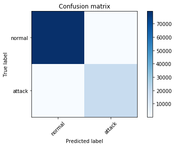

```
              precision    recall  f1-score   support

           0       1.00      1.00      1.00     79452
           1       1.00      0.99      1.00     19353

    accuracy                           1.00     98805
   macro avg       1.00      1.00      1.00     98805
weighted avg       1.00      1.00      1.00     98805

Score (RMSE): 0.036290038377046585
```

```python
pred3 = cnn.predict(x_test)
pred3 = np.argmax(pred2,axis=1)
y_true = np.argmax(y_test,axis=1)

# Compute confusion matrix
cm = confusion_matrix(y_true, pred3)
print(cm)

print('Ploting confusion matrix')
plt.figure()
plot_confusion_matrix(cm, ('normal','attack'))
plt.show()


print(classification_report(y_true, pred3))
print("Score (RMSE): {}".format(score2))
```

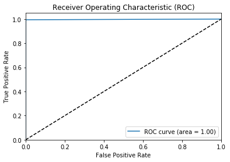

```python
plot_roc(pred3,y_true)
```